# What should I wear today?

## Prologue

Meet Shawna. Every morning before university, she faces the same question: “What should I wear today?” To help her decide, we observed people’s outfit choices across seasons.

This visual story is based on data collected in Auckland.

## What top should I wear?

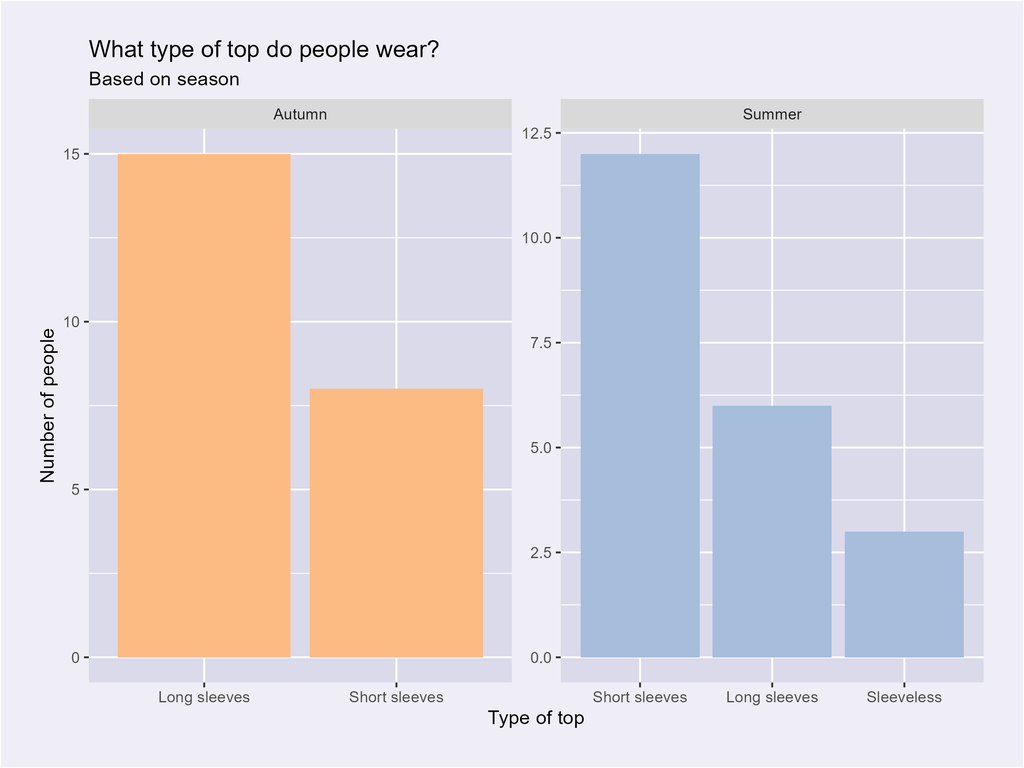

During autumn,

1. 65% of people wear a long-sleeved top
2. 35% of people wear a short-sleeved top
3. nobody wears a sleeveless top

During summer,

1. 57% of people wear a short-sleeved top
2. 29% of people wear a long-sleeved top
3. 14% of people wear a sleeveless top

**Let’s help Shawna decide what type of top to wear today!**

*About today:*

- Date: 13th May 2025
- Season: Autumn

Seems like Shawna should wear a **long-sleeved top** today.

## Now, what bottoms should I wear?

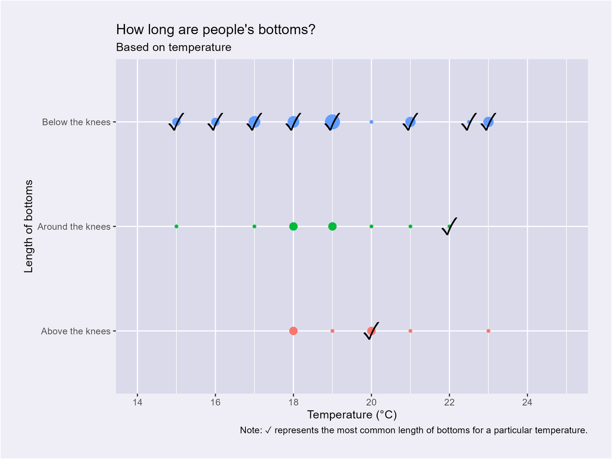

The most common length of bottoms for different temperature ranges has been summarised in the table below:

| Temperature Range (°C) | Length of Bottoms |
| --- | --- |
| 15–19 | Below the knees |
| 20 | Above the knees |
| 21 | Below the knees |
| 22 | Around the knees |
| 22.5–23 | Below the knees |

**Let’s inform Shawna about what bottoms to wear!**

*About today:*

- Current temperature: 16°C

Tell her to wear bottoms that reach **below the knees** so she can stay warm.

## Wait, does my outfit look weird?

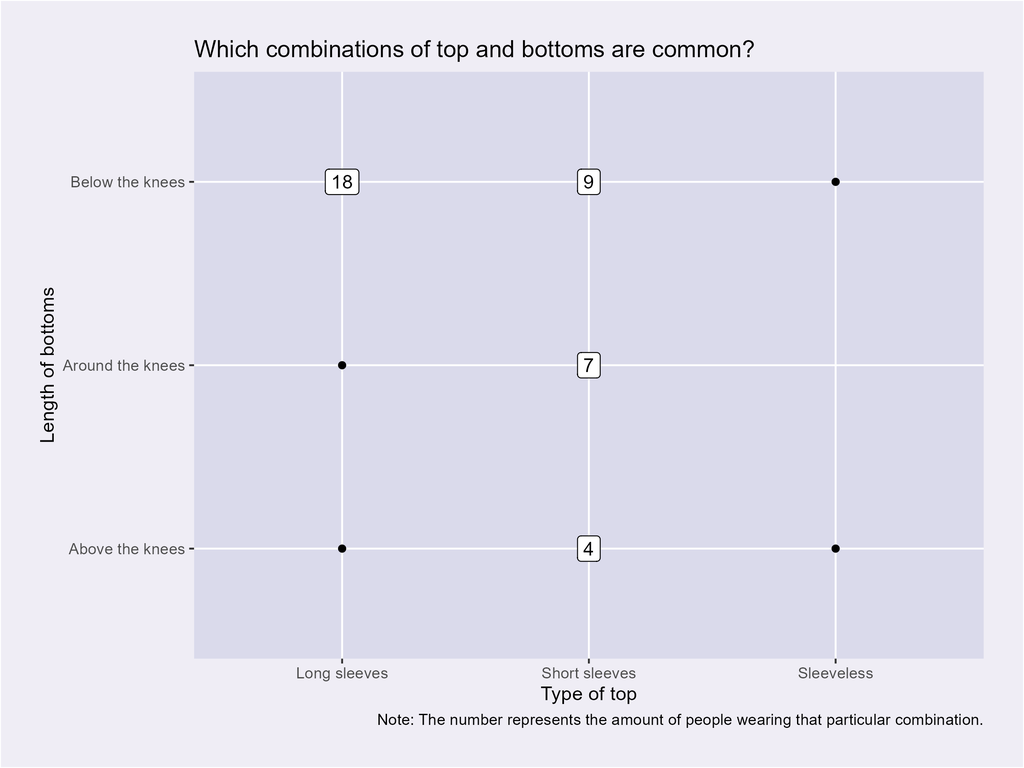

We consider a combination of top and bottoms to be “common” if more than 2 people (out of 44) have been seen wearing it. The common combinations of top and bottoms (in descending order) are:

|  | Top | Bottoms |
| --- | --- | --- |
| 1 | Long-sleeved | Below the knees |
| 2 | Short-sleeved | Below the knees |
| 3 | Short-sleeved | Around the knees |
| 4 | Short-sleeved | Above the knees |

**Shawna is worried that her outfit looks weird!**

*About her outfit:*

- Long-sleeved top
- Bottoms that reach below the knees

**Not weird** at all! In fact, that is how most people are dressed.

## Epilogue

By exploring the clothing patterns of other Aucklanders, we created a simple guide to help Shawna pick outfits that balance comfort and style, appropriate for the season.

Thanks to a bit of data, Shawna is ready to head out the door with confidence! 😃